# Red wine quality EDA by Alfred Wong

### *fixed.acidity.log10* and *density*

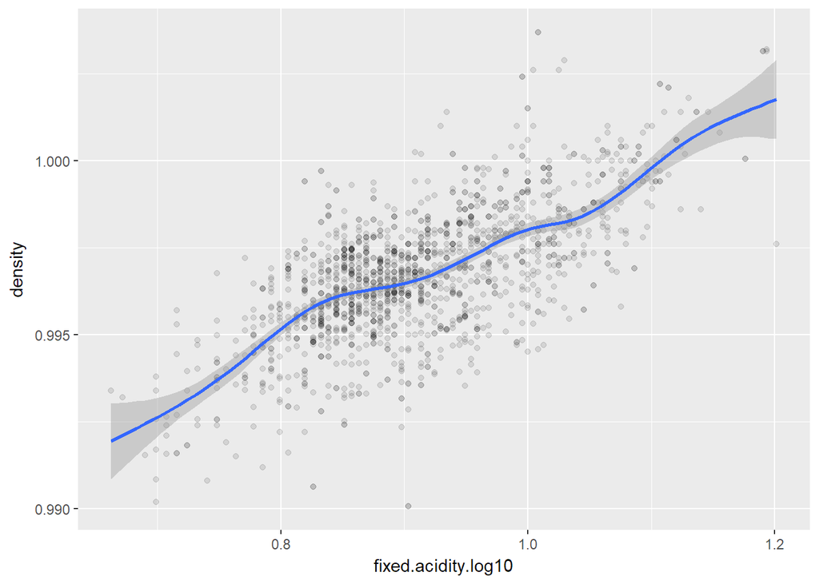

Correlation coefficient is 0.675.

### *residual.sugar.log10* and *density*

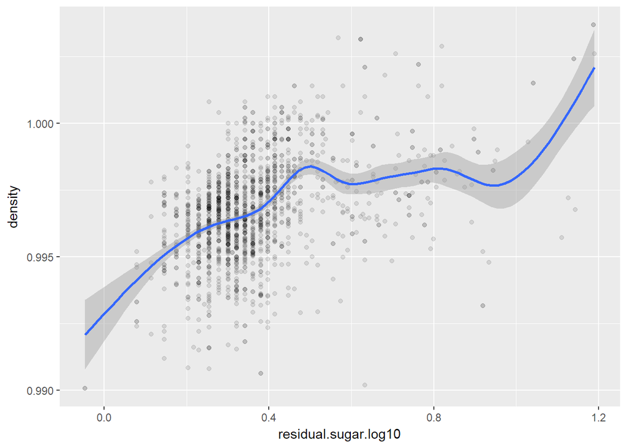

This plot may look a bit quirky, but in the left half of the plot that contains most of the observations, *density* actually shows a monotonic relationship with *residual.sugar* .

# Bivariate Analysis

Among the variables we have, we can see that quality is most strongly correlated with alcohol, followed by volatile.acidity and sulphates. Some other variables with weaker correlation are citric.acid, chlorides and bound.sulfur.dioxide.

The acid-related variables are often correlated with each other, and with pH as well, which makes sense. The odd one is volatile.acidity, which is negatively correlated with the other acid volumes and positively with pH.

Density is highly correlated with many variables such as fixed.acidity and alcohol.

The pair of variables with the strongest correlation is free.sulfur.dioxide and total.sulfur.dioxide.log10, with a coefficient of 0.714.

# Multivariate Plots Section

### The top 3 features and *quality*

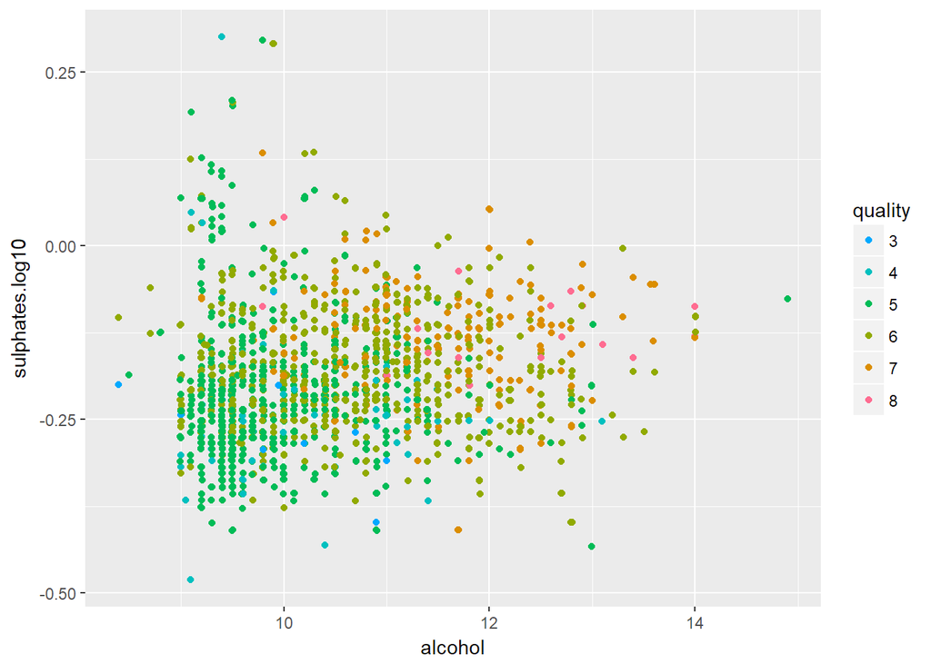

With two of our variables with the strongest correlation with quality, we can see the pattern clearly in this plot. *alcohol* and *sulphates* correlate positively with *quality*

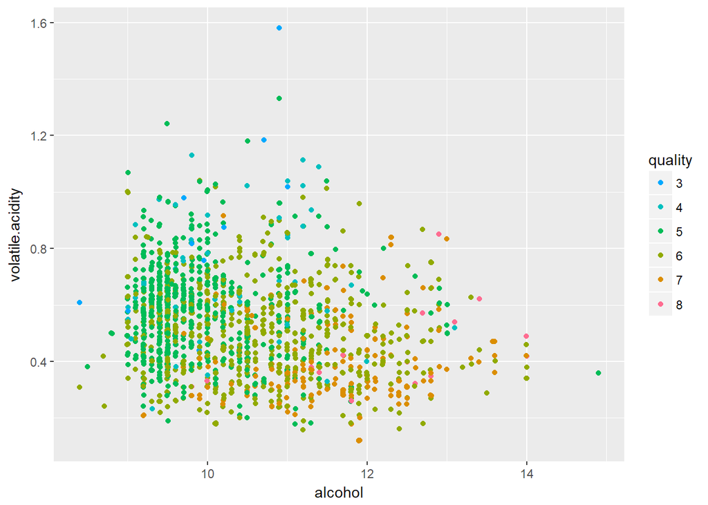

Again we can see that as the *quality* increases from blue to red, we go from the top left to bottom right in this plot, ie, lower *volatile.acidity* and higher *alcohol*.

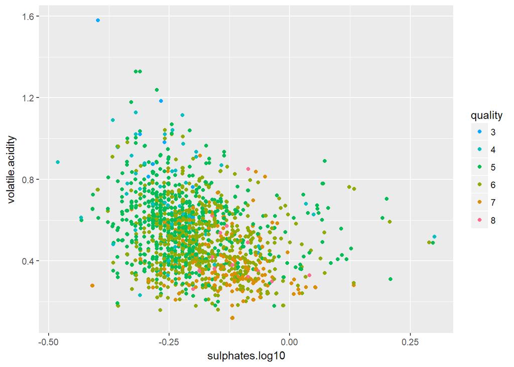

The patter is less pronounced in this plot as neither of the two variables here are as strongly correlated to *quality* as *alcohol*. But still the pattern is visible.

### *alcohol*, *density* and *quality*

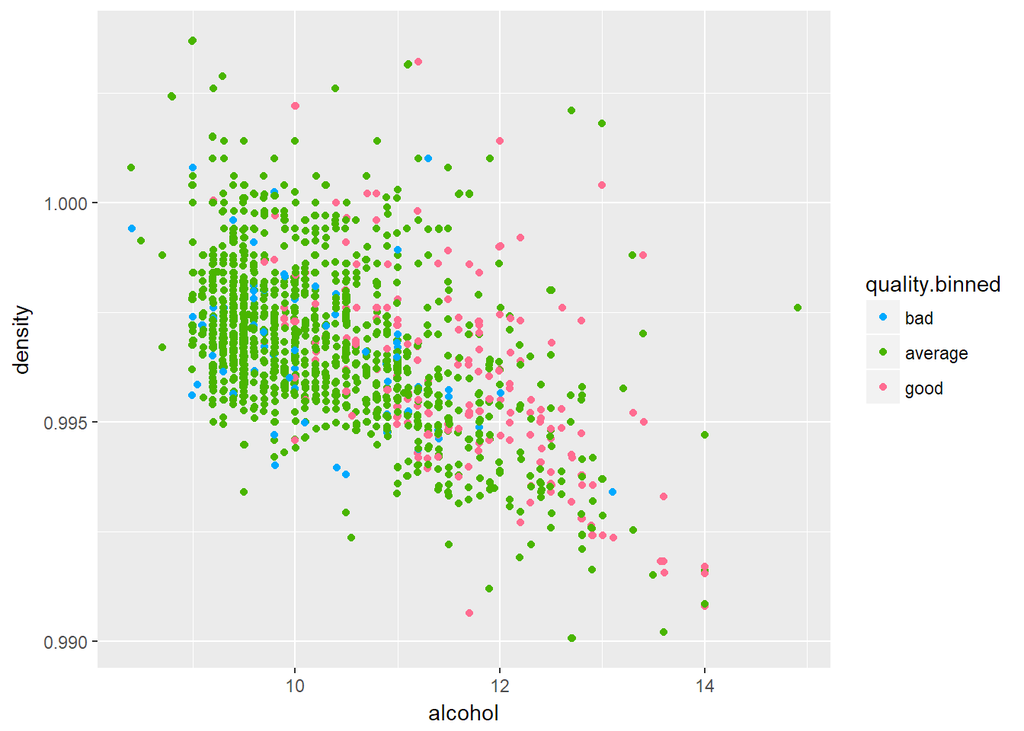

In this plot I use the binned quality (4 and below are bad, 5 and 6 average, 7+ are good). We lose some information details but this way the contrast is better and the pattern easier to see.

We can see that *density* has a negative relationship with *alcohol*, as alcohol is less dense than water. And it seems that among wines with the same alcohol content levels, the relationship between density and quality almost reverses, ie, the higher the density, the higher the quality.

I’d speculate that the negative correlation between density and quality is completely explained by its negative correlation with alcohol.

### Acidities and *pH*

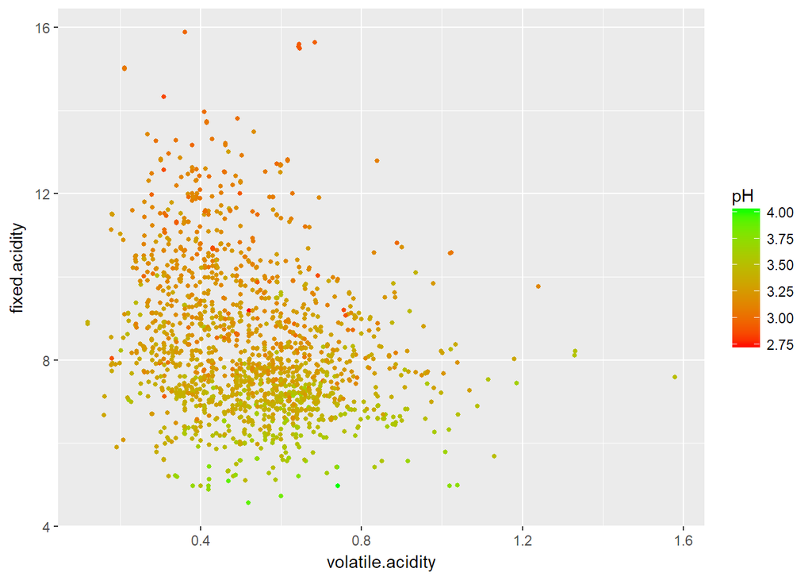

Lastly we take a look at how *pH* changes with our two acidity variables. The very pronounced pattern is the negative relationship between *fixed.acidity* and *pH*. But we also see that *pH* generally increases as *volatile.acidity* increases.

# Multivariate Analysis

In the previous section we found that *density* has a negative correlation with *quality*, but here it seems that when *alcohol* is in the equation the effect reverses.

Most other features behave the same way as we saw in the bivariate section.

# Final Plots and Summary

### Plot One

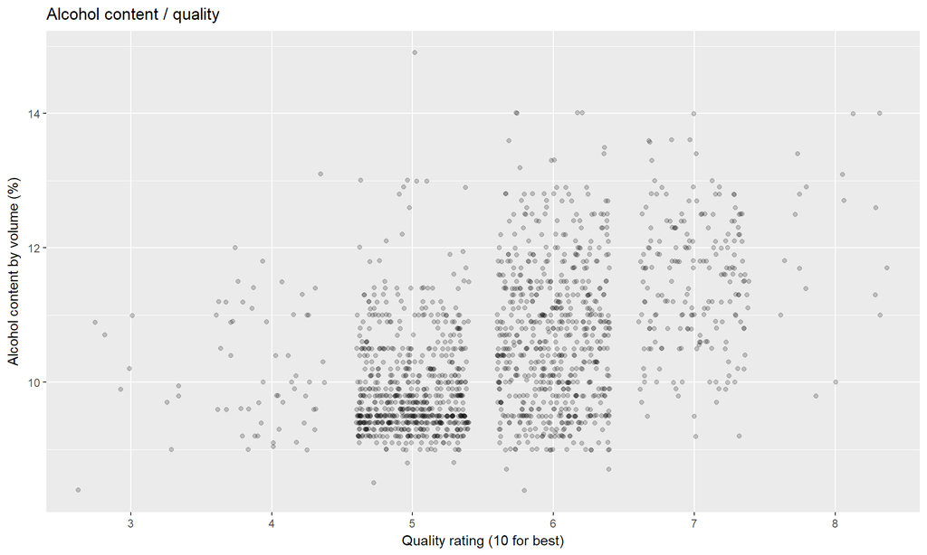

This plot, though simple, is important as *alcohol* has the strongest correlation with *quality* among all the features we have.

We can clearly see that the wines with higher alcohol content are rated higher. The difference is particularly pronounced between categories 6+ and those below 6.

### Plot Two

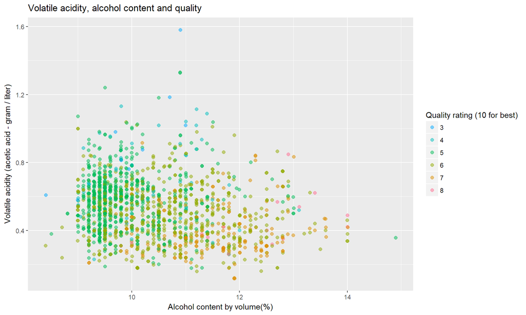

This plot shows the two features with the strongest correlation with *quality*, which means they probably are the best predictors of a wine quality we can find in this data set.

### Plot Three

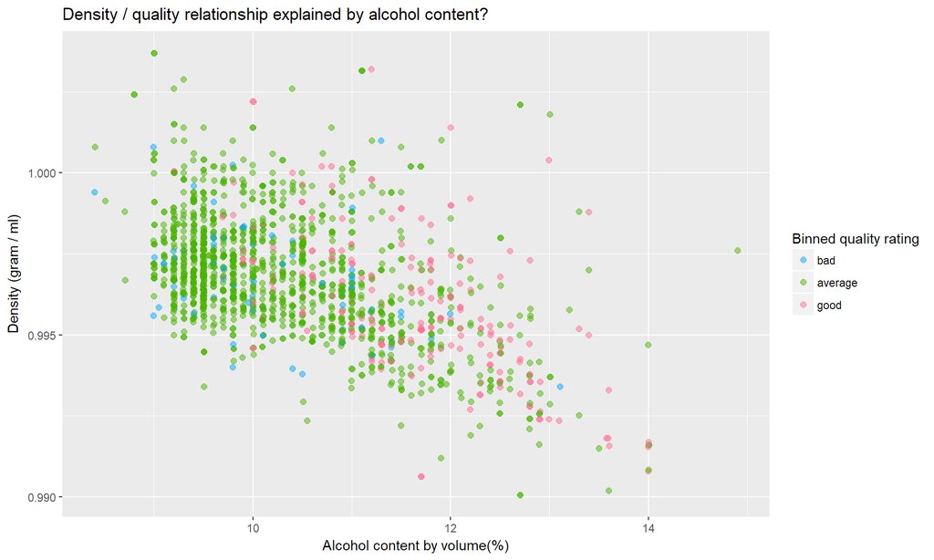

This plot is interesting in that we can see, contrary to what we’ve found in the bivariate analysis and correlation figures, once *alcohol* is accounted for, *density* seems to have a positive relationship with *quality*.

# Reflection

I am somewhat surprised to find that the strongest predictor we have of quality, at least when used alone, is such a simple, measureable and easily observable feature as alcohol content.

As far as I know, it isn’t extremely hard to increase the alcohol content by a a little when making wine. At least some of the makers who stop the fermentation early can stop doing that and let it finish?

But then it could be that some third factor causes both a higher alcohol content and better quality - imagine that better grapes make better wine, and better grapes are also suited to complete fermentation.

If there was such a factor, however, we can’t find it in our dataset. Statistical modeling or machine learning techniques may provide more insights.